# Calculations with p-adics

### **NOTES ON STATISTICS, PROBABILITY and MATHEMATICS**

### Calculations with p-adics:

#### Brief introduction:

P-adic numbers are power series:

$$s =\sum_{i=k}^\infty a_ip^i= a_kp^k +
a_{k+1}p^{k+1} +a_{k+2}p^{k+2} + \cdots$$
where $k$ is an integer and $0\leq a_i < p.$ These coefficients are the residue field (see below).

From [this YouTube video](https://youtu.be/vdjYiU6skgE?si=CXvf2qg98P_7sv_J):

The definition of the absolute value of the elements in a field determines the metric, which maps two elements of the field to a positive value.

The p-adic absolute value is defined as (for $\alpha \in \mathbb Q$)

$$\left| \alpha \right|_p = \left| p^n \,
\frac g h \right|_p = p^{-n}$$
This takes only discrete values $\left|\cdot\right|\in\{p^n:n\in\mathbb Z\}\cup\{0\}$, since $|0|_p=0$.

For a p-adic number represented as a power series, the absolute value is determined by the lowest exponent term with a non-zero coefficient. The term with the lowest exponent of $p$ signifies the highest power of $p$ that divides the number.

Examples:

For $p=11$ and $\alpha =968/9,$

$$\left| 968/9\right|_{11} = \left| 11^2
\, \frac{8}{9} \right|_{11} = 11^{-2}$$

In SageMath,

```
x = Qp(11)(968/9)
print(abs(x))
1/121 = 11^2
```

whereas

$$\left| 3-2\right|_{7}=
\left| 1\right|_{7}= \left| 7^0 \right|_{7} = 7^{0}=1$$

Or in 3-adic distance:

$1$ and $3$: Their difference $(2)$ is not divisible by $3$, so their $3$-adic distance is relatively large. $1$ and $10$: Their difference $(9)$ is divisible by $3^2$, making them closer in the $3$-adic sense.

This metric determines other seemingly puzzling results, such as the fact that in the $2$-adic sense

$$1 + 2 + 2^2 + 2^3 + 2^4 +
\cdots=\frac{1}{1-2}=-1$$

makes sense, based on the fact that the added values (in $2$-adic) are getting smaller and smaller. This is presented by 3B1B in [here](https://youtu.be/XFDM1ip5HdU?si=dQpqMighSDTuanK8).

The p-adic norm $\left|x \right|_p = p^{-\nu}$ has **power law behavior**. Because the norm is defined as a power of $p$, the addition of two p-adic numbers cannot result in a norm larger than the larger of the two individual norms. This is a characteristic feature of non-Archimedean spaces, where the usual additive properties of norms are replaced by the strong form of the triangle inequality, $\left|x+y \right|_p \leq \max(\left|x \right|_p, \left|y \right|_p)$.

Visualization of the p-adic norm as an infinity tree, corresponding to the power series. Each branch represents an element of the **residue field**: This is the set of numbers that remain after dividing all integers by $p$. For example, if $p=3$, the residue field would be $\{0, 1, 2\}$ because any integer divided by $3$ leaves a remainder of $0, 1, or 2$. The p-adic numbers are down at the boundary of this infinite tree. The p-adic norm can be interpreted as geodesic distances on this tree.

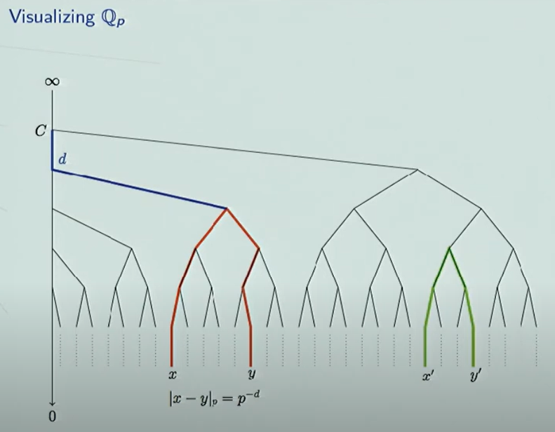

Here is a similar representation as a tree from [here](https://youtu.be/FnfnlrHBABs?si=6rYsA46aEokLAzPh):

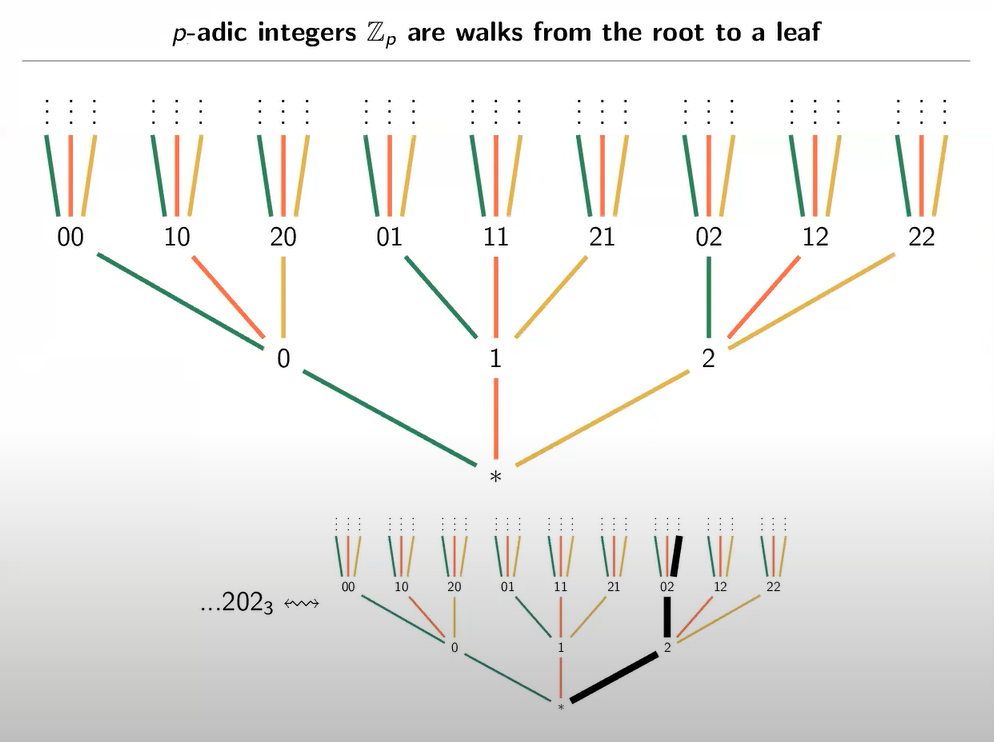

A p-adic integer is a walk up the tree from root to leaf, although one would never get to the leaf since p-adics are infinite expressions.

Examples of p-adic numbers in $\mathbb Q_5$ (from [here](https://youtu.be/vdjYiU6skgE?si=MG26Jpm-TSUqQUiP&t=724)):

$$\begin{align}
(1)_{\mathbb Q_5} &=1\\
(5)_{\mathbb Q_5} &= (0+ 1\times 5)_{\mathbb Q_5}=10\\
(-1)_{\mathbb Q_5} &=(4 + 4 \cdot 5 + 4 \cdot5^2+\cdots)_{\mathbb
Q_5}=...4444
\end{align}$$
because adding $...4444$ to $1$, which is $...000001$ will result in $0$ (additive inverse of one).

#### Fractions:

Simple algorithm compared to long division based on a couple of examples:

Based on [this YT presentation](https://youtu.be/cP0-69P2lJw?si=MzQmGH3S_VS1pEa-), let’s look first at the decimal expansion of $1/3$:

$$\frac 1 3 = \frac {c_0}{10^0} + \frac
{c_1}{10^1} + \frac {c_2}{10^2} + \frac {c_3}{10^3}+
\dots$$

Multiplying $\times 3$

$$1= 3\left(\frac {c_0}{10^0} + \frac
{c_1}{10^1} + \frac {c_2}{10^2} + \frac {c_3}{10^3}+ \dots
\right)$$

$c_0$, in $\frac{c_0}{10^0}$, multitplied times $3$ doesn’t fit into $1$, and hence $c_0$ is $0.\cdots$, and this gets us to the point when we have to add a zero $0$ to the right of $1$ to find $c_1$ (i.e. multiply $\times 10$). Naturally,

$$10 = 3\left( c_1 + \frac {c_2}{10^1} +
\frac {c_3}{10^2}+ \dots \right)$$

Now $3 c_1=10 \implies c_1 = 3$ and

$$1=10 - 9 = 3\left( \frac {c_2}{10^1} +
\frac {c_3}{10^2}+ \dots \right)$$

Again we have to multiply by ten:

$$10 = 3\left(c_2 + \frac{c_3}{10^1}+
\dots \right)$$

and we see that $C_2=3.$ Et cetera.

This is mirrored in the p-adics as follows.

#### Calculating p-adic expansions for fractions ($1/3$ in $5$-adic):

Example: calculate what $1/3$ is in $\mathbb Q_5:$

We want to express $1/3$ as a power series:

$$\frac 1 3 = a_0 + a_1\, p + a_2 \, p^2+
\dots$$

Rearranging:

$$1 = 3\left(a_0 + a_1\, p + a_2 \, p^2+
\dots \right)$$

If we express it $\mod 5$ the only term that will survive is the first

$$1 = 3\,a_0$$

and

$$a_0= 2$$

because

$$3\times 2 = 6 \equiv 1
\mod(5)$$

But we want finer refinement (inverse limit). Since the calculated $6$ is congruent to the LHS (i.e. $1$), the difference will be a multiple of $5$:

$$1 - 6=-5= 3\left(a_1\, p + a_2 \, p^2+
\dots \right)$$
Now dividing by $5$ on both sides, and since $p=5$:

$$-1 = 3\left(a_1 + a_2 \, p^1+ \dots
\right)$$

Given that $-1 \equiv 4 \mod(5)$, if we look at that equation $\mod 5$, all the powers of $p$ will be zero, allowing us to calculate that
$$a_1 =
3$$

since $3 \times 3 = 9\equiv 4 \mod(5).$ Note that the fact that the terms containing powers of $p$ go to zero doesn’t imply that the coefficients are zero.

Rinse and repeat:

$$-1 - 9= -10 = 3\left(a_2\, p + a_3 \,
p^2+ \dots \right)$$

Divide by $5$:

$$3 \mod(5) \equiv -2 = 3\left(a_2 + a_3
\, p+ \dots \right)$$

yielding

$$a_2=1$$

Rinse and repeat:

$$-2-3=-5 = 3\left( a_3\,p+ a_4\,p^2\dots
\right)$$

Divide by $5$:

$$4 \mod(5)\equiv -1 = 3\left( a_3+
a_4\,p\dots \right)$$

so
$$a_3=3$$

Et cetera.

$$\require{enclose}
\begin{array}{rll}
&
\color{blue}{2}\,\color{aqua}{3}\,\color{magenta}{1}\,\color{lime}{3}\dots \\[3pt]
3 &\enclose{longdiv}{\phantom{0}\color{brown}{\bf 1\equiv
1}}\kern-.2ex \\[3pt]
& \underline{-\,\color{orange}{\bf 6\equiv 1}} &&
\hbox{($\color{blue}{2} \times 3 =\color{orange}{\bf{6}}\equiv
\color{brown}{\bf{ 1}}\mod(5)$)}\quad\hbox{$\color{brown}{\bf
1}=3\,(\color{blue}2\,p^0 +x_1 \,p^1 + x_2 \,p^2+ x_3 \,p^3+\cdots)$}
\\[3pt]
&\color{red}{\bf{-5}}\phantom{0}\to \color{brown}{\bf{-1\equiv
4}} && \hbox{($\frac{\color{red}{\bf{-5}}}{p} =
\color{brown}{\bf{-1}}\equiv
4\mod(5)$)}\quad\hbox{$\frac{\color{red}{\bf{-5}}}{p}=3\,(x_1 +
x_2\,p^1+ x_3\,p^2+\cdots)$} \\[3pt]
&\phantom{0000000}\underline{-\,\color{orange}{\bf 9\equiv
4}\phantom{0}} && \hbox{($\color{aqua}{3} \times 3
=\color{orange}{\bf 9} \equiv 4 \mod(5)$)}
\quad\hbox{$\color{brown}{\bf{-1}}=3\,(\color{aqua}3\,p^0 + x_2\,p^1+
x_3\,p^2+\cdots)$}\\[3pt]
&\phantom{000000}\color{red}{\bf{-10}} \phantom{0}\to
\color{brown}{\bf{-2\equiv 3}} &&
\hbox{($\frac{\color{red}{\bf{-10}}}{p} = \color{brown}{\bf{-2}}\equiv
3\mod(5)$)}\quad\hbox{$\frac{\color{red}{\bf{-10}}}{p}=3\,(x_2+
x_3\,p+\cdots)$} \\[3pt]
&\phantom{00000000000000}\underline{-\,\color{orange}{\bf{3\equiv
3}}} && \hbox{($\color{magenta}{1} \times 3 =
\color{orange}{\bf{3}}\equiv
3\mod(5)$)}\quad\hbox{$\color{brown}{\bf{-2}}=3\,(\color{magenta}1\,p^0
+ x_3\,p^1+\cdots)$} \\[3pt]
&\phantom{00000000000000}\color{red}{\bf{-5}} \to
\color{brown}{\bf{-1\equiv 4}} &&
\hbox{($\frac{\color{red}{\bf{-5}}}{p} = \color{brown}{\bf{-1}}\equiv
4\mod(5)$)}\quad\hbox{$\frac{\color{red}{\bf{-5}}}{p}=3\,(x_3+\cdots)$}
\\[3pt]
&\phantom{00000000000000000000}\underline{-\,\color{orange}{\bf{9\equiv
4}}} && \hbox{($\color{lime}{3} \times 3 =
\color{orange}{\bf{9}}\equiv
4\mod(5)$)}\quad\hbox{$\color{brown}{\bf{-1}}=3\,(\color{lime}3\,p^0
+\cdots)$}\\[2pt]
&\phantom{00000000000000000000}\color{red}{\bf{-10}}\\[2pt]
&&\phantom{000000000}\vdots
\end{array}$$

$$\left(1/3 \right)_{\mathbb Q_5}= 2 + 3
\cdot 5 + 1 \cdot 5^2 + 3 \cdot 5^3 + \cdots$$
Notice that the algorithm keeps reducing the remainder modulo $5$, as we get the coefficients for higher and higher $p^n$ values. This is akin to adding a $0$ to the remainder to keep dividing $1$ into $3$ in the process of getting the decimal expression of $1/3,$ with each $0$ added to the remainder equivalently contributing to higher and higher $10^{-n}$ values in the decimal expression.

In SageMath:

```
padic_printing.mode('digits')
print(Qp(5)(1/3))
...31313131313131313132
padic_printing.mode('series')
print(Qp(5)(1/3))
2 + 3*5 + 5^2 + 3*5^3 + 5^4 + 3*5^5 + 5^6 + 3*5^7 + 5^8 + 3*5^9 + 5^10 + 3*5^11 + 5^12 + 3*5^13 + 5^14 + 3*5^15 + 5^16 + 3*5^17 + 5^18 + 3*5^19 + O(5^20)
```

$$...31313131313131313132 = 2 + 3\cdot 5 +
5^2 + 3\cdot 5^3 + 5^4 + 3\cdot 5^5 + 5^6 + 3\cdot 5^7 + 5^8 + 3\cdot
5^9 + 5^{10} + 3\cdot 5^{11} + O(5^{12})$$

Another example: $2/3$ in $5$-adic:

In Sagemath:

```
padic_printing.mode('digits')
print(Qp(5)(2/3))
...13131313131313131314
padic_printing.mode('series')
print(Qp(5)(2/3))
4 + 5 + 3*5^2 + 5^3 + 3*5^4 + 5^5 + 3*5^6 + 5^7 + 3*5^8 + 5^9 + 3*5^10 + 5^11 + 3*5^12 + 5^13 + 3*5^14 + 5^15 + 3*5^16 + 5^17 + 3*5^18 + 5^19 + O(5^20)
```

$$2 = 3\left(a_0 + a_1\, p + a_2 \, p^2+
\dots \right)$$

$$a_0=4$$

because $3 \times 4 = 12\equiv2 \mod(5)$

Now

$$2-3 \times 4= -10 = 3\left(a_1\, p + a_2
\, p^2+ \dots \right)$$

Divide by $5$

$$3 \mod(5)\equiv -2 = 3\left(a_1 + a_2 \,
p+ \dots \right)$$

yields

$$a_1 = 1$$

and therefore

$$-2 -3=-5= 3\left(a_1 + a_2 \, p+ \dots
\right)$$

divide by $5$

$$4 \mod(5)\equiv -1 = 3\left( a_2 + a_3\,
p+ \dots \right)$$

and

$$a_2=3$$

Subtract

$$-1 - 9=-10= 3\left(a_3\, p+ \dots
\right)$$

Divide by $5$

$$3\mod(5)\equiv-2= 3\left(a_3\, p+ \dots
\right)$$

yielding

$$a_3=1$$

And so on.

Notice that this would break if we tried $1/24$ in $2$-adics:

$$1=24\, (a_0+ a_1 \,p + a_2
\,p^2+\dots)$$

because there is no number $n$ such that $24 \, n\equiv 1\mod(2).$ Hence we we’ll need the factorization trick explained below with $1/24= 1/3\times 2^{-3}.$

[Wikipedia example](https://en.wikipedia.org/wiki/P-adic_number) of $1/5$ in $3$-adics:

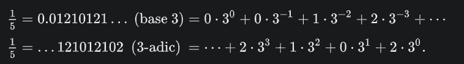

$$\require{enclose}
\begin{array}{rll}
&
\color{blue}{2}\,\color{red}{0}\,\color{magenta}{1}\,\color{lime}{2}\dots \\[-3pt]
5 &\enclose{longdiv}{\phantom{0}1}\kern-.2ex \\[-3pt]
& \underline{-10} && \hbox{($\color{blue}{2} \times 5
= 10\equiv 1\mod(3)$)} \\[-3pt]
&-9\phantom{0}\to -3 && \hbox{($-9/p = -3\equiv
0\mod(3)$)}\,\hbox{($-9/p=5(x_1 + x_2p^1+ x_3p^2+\cdots)$)} \\[-3pt]
&\phantom{0000000}\underline{-0\phantom{0}} &&
\hbox{($\color{red}{0} \times 5 =0 \equiv 0 \mod(3)$)} \\[-3pt]
&\phantom{000000}-3 &\to -1 & \hbox{($-3/p = -1\equiv
2\mod(3)$)}\,\hbox{($-3/p=5(x_2+ x_3p+\cdots)$)} \\[-3pt]
&&\phantom{000}\underline{-5} &
\hbox{($\color{magenta}{1} \times 5 = 5\equiv 2\mod(3)$)} \\[-3pt]
&&\phantom{00}-6 \to -2 & \hbox{($-6/p = -2\equiv
1\mod(3)$)}\,\hbox{($-6/p=5(x_3+\cdots)$)} \\[-3pt]
&&\phantom{00000000}-10 & \hbox{($\color{lime}{2}
\times 5 = 10\equiv 1\mod(3)$)}\\[-3pt]
&&&\vdots
\end{array}$$

In SageMath the $3$-adic expansion is:

```
padic_printing.mode('series')
print(Qp(3)(1/5))
2 + 3^2 + 2*3^3 + 3^4 + 3^6 + 2*3^7 + 3^8 + 3^10 + 2*3^11 + 3^12 + 3^14 + 2*3^15 + 3^16 + 3^18 + 2*3^19 + O(3^20)
padic_printing.mode('digits')
print(Qp(3)(1/5))
...21012101210121012102
```

whereas base $3$ base expression is

$$0.012101210121\dots_3$$

Notice that the expansion of $5$ in $3$-adic may look similar in structure:

[output not shown]

but it ends: after a certain coefficient, the rest are all zeros:

```
padic_printing.mode('digits')
print(Qp(3)(5))
...00000000000000000012
```

#### p-adic expansion of integers:

P-adics expand to infinity on to the left as in $\mathbb Z_3,$ corresponding to the $3$-adics. For example, in this system the number $3$ is

$$...00000000000000000010 = 0 \cdot 3^0 +
1 \cdot 3^1$$

In Sage

```
padic_printing.mode('digits')
print(Zp(3)(3))
...000000000000000000010
padic_printing.mode('series')
print(Zp(3)(3))
3 + O(3^21)
```

For natural numbers, the p-adic representation and the base-p representation are essentially the same. For natural numbers, the p-adic representation will have only a finite number of non-zero terms, effectively reducing to the base-p representation.

For example, compare the $5$-adic expansion of $233$

$$...00000000000000001413 = 3 \cdot 3^0 +
1 \cdot 5^1 + 4\cdot 5^2 + 1\cdot 5^3+\cdots$$

```
padic_printing.mode('series')
print(Qp(5)(233))
3 + 5 + 4*5^2 + 5^3 + O(5^20)
padic_printing.mode('digits')
print(Qp(5)(233))
...00000000000000001413
```

to the expression mod $5$:

$$233 \mod(5)= 3 + 1 \cdot 5^1 + 4 \cdot
5^2 + 1\cdot 5^3$$

```
a = 233
base = 5
print(" + ".join([f"{digit}*{base}^{i}" if i > 0 else str(digit) for i, digit in enumerate(a.digits(base)) if digit]))
3 + 1*5^1 + 4*5^2 + 1*5^3
```

The negative reals are simply the additive inverses of their positive counterparts, so $-1 = ...11111111$

Because

$$...11111111 + ...00000001 =
...000000$$

since in base $2$ and summing from right to left, $1 + 1 = 0$ and we carry $1$ to the left to add it to the $1$ in the second position in the expression of $-1.$

#### Negative integers:

Example:

$2$-adic representation of $-33$: We want to find a $2$-adic number $x$ such that $x + 33 = 0$ (in the $2$-adic field). We can compute this by finding the inverse of $33$ in the $2$-adic field:

```
padic_printing.mode('digits')
print(Qp(2)(33))
...00000000000000100001
padic_printing.mode('digits')
print(Qp(2)(-33))
...11111111111111011111
```

#### Negative exponents in p-adics:

Negative exponents typically come into play when dealing with fractions or representing very small numbers in the p-adic number system.

In the p-adic number system, fractions that involve negative exponents emerge when the denominator of the fraction is divisible by $p$, the base of the system. This is because the p-adic expansion needs to represent the fractional part appropriately by incorporating terms with negative exponents. Let’s consider an example in the $5$-adic system: Let’s take $1/25$. Convert to $5$-adic Expansion: $1/25=5^{−2}$.

```
padic_printing.mode('digits')
print(Qp(5)(1/25))
...000000000000000000.01
padic_printing.mode('series')
print(Qp(5)(1/25))
5^-2 + O(5^18)
```

Here is another example of negative exponents, which correspond to digits to the right of the period. When you see a p-adic number written with digits to the right of a “p-adic point” (or sometimes represented with negative powers of p explicitly), it indicates that the number is not a p-adic integer. It is a p-adic number that lies in the fraction field of the p-adic integers. In this case it is the $2$-adic expression of $\frac{1}{2^5 \cdot33}:$

[output not shown]

#### Digits to the right of the period in $p$-adic expressions (e.g. $.011$):

How are the finite digits ($.011$) to the right of the period calculated in an expression such as $...10101010101010101.011$, and where do they come from?

The issue comes up in the introduction of $\mathbb Q_p$ numbers. For instance, in the case of the 2-adic expression of $\frac 1{24}$. P-adic numbers can be factored as

$$n = p^k \, \text{unit}$$
where $k$ is an exponent measuring the valuation of the p-adic as $\frac 1{p^k}$, and the $\text{unit}$ is… well quick review:

> A **unit** in a ring is an element that has a multiplicative inverse. In other words, if $a$ is a unit, there exists an element $b$ in the ring such that $a \cdot b = 1$. A **zero divisor** is a non-zero element $a$ in a ring such that there exists a non-zero element $b$ where $a \cdot b = 0.$

Therefore, in the case of a fraction:

$$\frac m n = \frac m{p^k} \frac
1{\text{unit}}= \frac m{\text{unit}}p^{-k}$$

Applying it to the example of $1/24,$ the denominator can be factorized as $2^3 \cdot 3:$

$$\frac 1{24}=\frac 1 3 \cdot
2^{-3}$$

$1/3$ is just the multiplicative inverse of $3,$ which can be obtained in sagemath as:

```
from sage.all import *
from sage.rings.padics.padic_printing import pAdicPrinter
padic_printing.mode('digits')
print(Qp(2)(1/3))
# ...10101010101010101011
```

and easily confirmed to be accurate:

```
third = Qp(2)(1/3)
three = Qp(2)(3)
print(third * three)
# ...00000000000000000001
```

Therefore,

$$1/24 = ...10101010101010101011 \cdot
2^{-3}$$

but since we are operating in base $2,$ the factor $2^{-3}$ just moves the period to the right, like $10^{-3}$ would in base $10.$ In this way, we get the final result:

$$1/24=...10101010101010101.011=1\cdot2^{-3} +
1\cdot2^{-2}+0\cdot2^{-1}+1\cdot2^{0} + 0\cdot2^{1}+
1\cdot2^{2}+0\cdot2^{3}+1\cdot2^{4}$$

or in sagemath

```
padic_printing.mode('digits')
print(Qp(2)(1/24))
...10101010101010101.011
padic_printing.mode('series')
print(Qp(2)(1/24))
2^-3 + 2^-2 + 1 + 2^2 + 2^4 + 2^6 + 2^8 + 2^10 + 2^12 + 2^14 + 2^16 + O(2^17)
```

#### p-adic use in computers:

Suppose our computer stores the following 5-adic number: $...4321$ (where the digits extend infinitely to the left). However, the computer can only store the last four digits: $4321$.

1. Interpretation as a Base-5 Number:

We treat the stored digits, $4321$, as a base-$5$ number.

2. Conversion to Base-10 (Decimal):

We convert this base-5 number to its decimal (base-10) equivalent:

$4 * 5³ + 3 * 5² + 2 * 5¹ + 1 * 5⁰ = 4 * 125 + 3 * 25 + 2 * 5 + 1 * 1 = 500 + 75 + 10 + 1 = 586$

Computers typically use floating-point representation for real numbers. This allows them to represent a wide range of numbers, both very small and very large, with reasonable precision. Computer hardware is designed to perform arithmetic on binary numbers, which are used to represent integers and floating-point numbers. There is no direct hardware support for p-adic arithmetic. Any p-adic calculations would have to be implemented in software, which would be slower.

#### Hensel’s lemma:

A **simple root** of a polynomial is a root where the polynomial crosses the x-axis and does not touch or bounce off it. A root $r$ of a polynomial $f(x)$ is considered simple if $f(r) = 0$ and the derivative $f'(r)\neq 0$. This means that at $r$, the polynomial has a non-zero slope, indicating that it crosses the x-axis at that point. In contrast, a multiple root (or repeated root) would satisfy $f(r) = 0$ and $f’(r) = 0$, meaning the polynomial touches or bounces off the x-axis at $r$ but does not cross it.

If a polynomial has a simple root modulo a prime $p$, Hensel’s theorem allows us to lift this root to a root modulo $p^k$ for any $k$. This process can be extended to find roots in the p-adic integers $\mathbb{Z}_p$.

$$a_{n+1}\equiv a_n
\mod{p^{n+1}}$$

and

$$f(a_n)\equiv 0 \mod
{p^{n+1}}$$

will allow the construction of a sequence of entries in the p-adic expression.

For instance (see [here](https://youtu.be/gsg1x6mxVIA?si=EPeR-rniYi6wkq6D)), $f(x) = x^2 + 1$ has two solutions $\mod{5}$: $3$ with multiplicity $1$, and $2$ with multiplicity $1.$

```
R.<x> = GF(5)[]
p = x^2 + 1
p.roots()
# [(3, 1), (2, 1)]
```

These will start the sequence in the p-adic (of $5$-adic) expansion. So for $r = 2,$ this will be $a_0=2.$ For $a_1,$ the equation above is

$$\begin{align} a_1 &\equiv a_0
\mod{5^1}\\
a_1 &\equiv 2 \mod{5} \\
a_1 &= 2 + 5t
\end{align}$$

and

$$\begin{align}
f(a_1) &\equiv 0 \mod{5^2}\\
(2 + 5t)^2 + 1 &\equiv 0 \mod{5^2} \\
t &\equiv 1 \mod {5^2}
\end{align}$$

yielding

$$\begin{align}
a_1 = 2 + 5 \cdot 1 =7
\end{align}$$

And at this point we are ready for

$$\begin{align}
a_2 &\equiv a_1 \mod{5^2}\\
a_2 &\equiv 7 \mod{25}\\
a_2 &= 7 +25t
\end{align}$$

and
$$(7 +25t)^2+1 \equiv 0
\mod{5^3}$$

which results in $a_2 =57.$

Progressing to

$$\begin{align}
a_3 &\equiv a_2 \mod{5^3}\\
a_3 &\equiv 57 \mod{125}\\
a_3 &= 57 +125t
\end{align}$$

which can be plugged into the function:

$$(57+125t)^2 + 1\equiv 0
\mod{5^4}$$

resulting in $t=1$ and $a_3 =57 + 125 = 182$

In sagemath,

```
import numpy as np

def hensel(roots, p):
    first_root = roots[0][0]
    scnd_root = roots[1][0]
    first_root_str = str(first_root).replace('...', '')
    first_root_list = [int(digit) for digit in first_root_str]
    first_root_list_reversed = first_root_list[::-1]
    first_result = [digit * (p ** i) for i, digit in enumerate(first_root_list_reversed)]
    scnd_root_str = str(scnd_root).replace('...', '')
    scnd_root_list = [int(digit) for digit in scnd_root_str]
    scnd_root_list_reversed = scnd_root_list[::-1]
    scnd_result = [digit * (p ** i) for i, digit in enumerate(scnd_root_list_reversed)]

    return [np.cumsum(first_result), np.cumsum(scnd_result)]
padic_printing.mode('series')
R.<x>  = Qp(5,8)[]
p = x^2 + 1
p.roots()
#[(2 + 5 + 2*5^2 + 5^3 + 3*5^4 + 4*5^5 + 2*5^6 + 3*5^7 + O(5^8), 1),
 (3 + 3*5 + 2*5^2 + 3*5^3 + 5^4 + 2*5^6 + 5^7 + O(5^8), 1)]
padic_printing.mode('digits')
R.<x> = Qp(5,8)[]
p = x^2 + 1
p.roots()
#[(...32431212, 1), (...12013233, 1)]
roots = p.roots()
hensel(roots, 5)
#[array([     2,      7,     57,    182,   2057,  14557,  45807, 280182]),
 array([     3,     18,     68,    443,   1068,   1068,  32318, 110443])]
```

Notice how this makes sense:

```
2 + 5 + 2*5^2 = 57
```

[Home Page](http://rinterested.github.io/statistics/index.html)

**NOTE: These are tentative notes on different topics for personal use - expect mistakes and misunderstandings.**